# Individual Project Theme 3

## Simple Calculator

**How to use this notebook and complete the project?**

1. You need to answer all required questions by answering in the markdown cell.
2. Read the instruction and fill in the #todo sections.
3. Run all the cells to store the results of each codes.
4. Save this notebook by clicking on `File`, then click `Download as`, choose `HTML`.
5. Push this notebook to your GitHub reporitory by creating a new repository, named `AIP_IndividualProject`. Set this repository as `Private` until the day of your submission, which is on *29th June 2019, 1.30 PM*.

**Introduction**

Imagine you are going to program a simple calculator like the picture below.

[figure not shown]

Basic calculations for calculator, are addition, subtraction, multiplication and division. Note that the calculator is not going to do a calculation for whole numbers only, decimals are also involved.

**Question 1**:

Draw a flowchart to write the program of this task. You may draw a flowchart by using *powerpoint*, then save it as a picture in `.jpg` or `.png`. Then, use this command to the *Answer* column below. `<img src=_____.jpg>`

**Answer**:

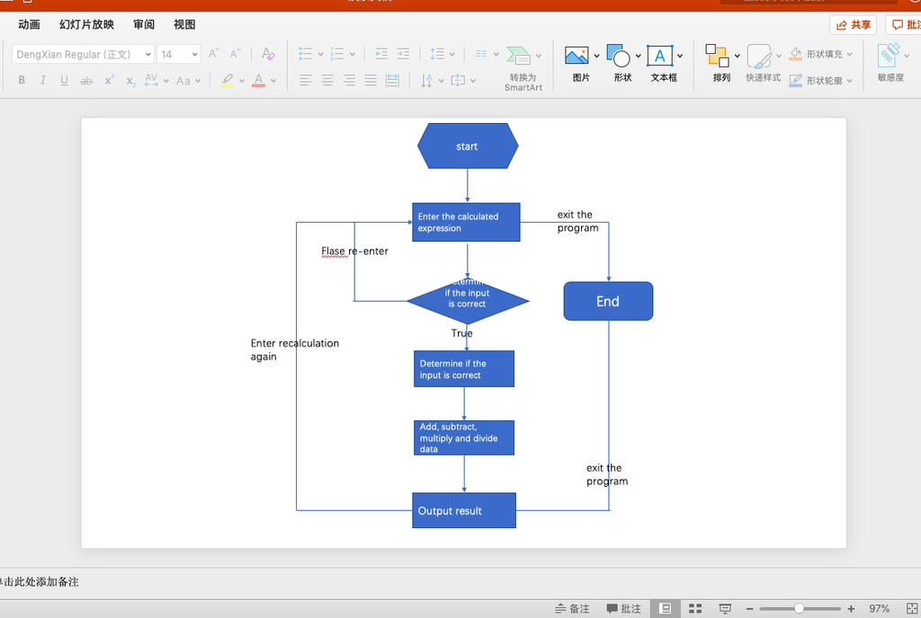

**Step 1**:

# TODO

Ask users for input. We’ll start writing our program at the point where the human enters the numbers that they would like the computer to work with. For this program, we would like the user to input two numbers, so let’s have the program ask for two numbers. When asking for input, we should include a space at the end of our string so that there is a space between the user’s input and the asked string.

```python
#TODO
#Ask user for two inputs

number_1, number_2 = input("Please input two number").split()
```

```
Please input two number1 1.5
```

**Step 2**

# TODO

By using `try` and `except` statement, write down a function to determine whether input numbers are integers or decimals.

```python
#TODO

def number_type(number):
    try:
        number = int(number)
    except ValueError:
        number = float(number)
    return number

num_1 = number_type(number_1)
num_2 = number_type(number_2)
print(type(num_1), type(num_2))
```

```
<class 'int'> <class 'float'>
```

**Step 3**

# TODO

We’ll name the function `calculate()` and add an additional layer of indentation within the function itself. Function `calculate()` is defining arithmetic operations.

```python
#TODO

def calculate(num_1, num_2, operation):
    #addition
    if operation == '+':
        return num_1 + num_2
    #subtraction
    elif operation == '-':
        return num_1 - num_2
    #multiplication
    elif operation == '*':
        return num_1 * num_2
    #division
    elif operation == '/':
        return num_1 / num_2

    return None
```

**Step 4**

# TODO

Define an `again()` function to ask user either he/she wants to do a a calculation again or not.

```python
#TODO
def again(calc_again, previous):
    if calc_again.upper() == 'YY' or calc_again.upper()  == 'Y':
        operation = input("Please type the operation that you would like to complete (+, -, * or /): ")
        num_2 = input("Please input a num")
        num_2 = number_type(num_2)
        return calculate(previous, num_2, operation)
    else:
        return 'See you later.'
```

**Step 5**

Write a `while` loop to operate the calculator until it says No and `break` the loop.

```python
operation = input("Please type the operation that you would like to complete (+, -, * or /): ")
result = calculate(num_1, num_2, operation)
print(result)

#TODO
while True:             # Loop continuously
    calc_again = input("Are you want to do a a calculation again?")
    result = again(calc_again, result)
    if result == 'See you later.' or result is None:
        break
    print(result)
```

```
Please type the operation that you would like to complete (+, -, * or /): -
-0.5
Are you want to do a a calculation again?y
Please type the operation that you would like to complete (+, -, * or /): +
Please input a num0.5
0.0
Are you want to do a a calculation again?y
Please type the operation that you would like to complete (+, -, * or /): +
Please input a num0.5
0.5
Are you want to do a a calculation again?n
```

**BONUS**

Add complicated operations in your calculator. For example, calculation a square root or root of a number by using $\surd$

```python
num = float(input('Please enter a number： '))
num_sqrt = num ** number
print(' The square root of %0.3f is %0.3f'%(num ,num_sqrt))
```

[output not shown]

**Question 2**:

How would you like to improve your calculator codes?

**Answer**:

```python
Make it easier to get started, easy to understand
```